# Summary Statistics

STAT 240 - Fall 2025

Robert Sholl

# Math Review

## Rules

1. **Commutative rule**
   - Order doesn’t matter
2. **Associative rule**
   - Order still doesn’t matter
3. **Distributive rule**
   - Order matters sometimes

## Commutative Rule

> When two terms are added$^1$, order does not matter

$$(a + b) = (b + a)$$

> When two terms are multiplied$^2$, order does not matter

$$(a \times b) = (b \times a)$$

$^1$ subtraction is just negative addition

$^2$ division is just fraction multiplication

## Quick note

**Subtraction is addition**

$$\begin{aligned}
a - b = a + (-b) \\
\\
10 - 5 = 5 \\
\\
10 + (-5) = 5 \\
\\
10 - 5 = 10+(-5) \\
\end{aligned}$$

## Quick note

**Division is multiplication**

$$\begin{aligned}
a/b= a\times 1/b \\
\\
10/5= 2 \\
\\
10 \times 1/5= 2\\
\\
10/5= 10 \times 1/5
\end{aligned}$$

## Associative Rule

> When $\ge 3$ terms are added, order does not matter

$$a+(b+c)=(a+b)+c$$

> When $\ge 3$ terms are multiplied, order does not matter

$$a \times (b \times c) = (a \times b) \times c$$

## Distributive Rule

> When a term is multiplied over the addition of two terms, the result is an output equal to the sum of their individual products with the first term

$$\begin{aligned}
a \times (b+c) = (a \times b) + (a \times c) \\
\\
5 \times(10+2)=5 \times 12=60\\
\\
(5 \times 10) + (5 \times 2) = 50 + 10 = 60
\end{aligned}$$

## PEMDAS

1. Parentheses
2. Exponents
3. Multiplication and Division
4. Addition and Subtraction

## Basic Exponent Properties

$$\begin{aligned}
& a^m \times a^n= a^{m+n} \\
& \frac{a^m}{a^n}=a^{m-n}\\
& a^0=1\\
& a^{-m}=\frac{1}{a^m}\\
& (a^m)^n=a^{m\times n}\\
& (ab)^m=a^m\times b^m \\
& \left(\frac{a}{b} \right)^m=\frac{a^m}{b^m}
\end{aligned}$$

## Logarithms

$$\begin{aligned}
10^3& =1000 \\
\log_{10}(1000)& =3 \\
\\
a^b& =c \\
\log_a(c)& =b \\
\\
\log_a(xy)& =\log_a(x)+\log_a(y)\\
\log_a(x/y)& =\log_a(x)-\log_a(y)\\
\log_a(x^y)& =y\log_a(x)
\end{aligned}$$

## Equalities

$$\begin{array}{|c|c|}
\hline
= & \text{Is equal to}\\
\hline
\equiv & \text{Is defined as}\\
\hline
\approx & \text{Is approximately}\\
\hline
< & \text{Is less than}\\
\hline
> & \text{Is greater than}\\
\hline
\le & \text{Is less than or equal to} \\
\hline
\ge & \text{Is greater than or equal to}\\
\hline
\end{array}$$

## Some Definitions

$$\begin{aligned}
\pi \approx 3.14 \\
\\
\tau = 2\pi \\
\\
e \approx 2.718 \\
\\
\log = \log_{10}\\
\\
\ln = \log_e \\
\end{aligned}$$

## Univariate Solutions

# Notation

We’re doing Greek letters now

## Denoting Data

$$\begin{array}{|c|c|}
\hline
n & \text{Sample size} \\
\hline
N & \text{Population size} \\
\hline
x, \ y, \ z & \text{(conventionally) Data} \\
\hline
i,\ j & \text{Indices} \\
\hline
x_i, \ y_j & \text{Indexed data} \\
\hline
\text{Lowercase Greek letters} & \text{Population parameters} \\
\hline
\text{Lowercase Arabic letters} & \text{Sample statistics} \\
\hline
\end{array}$$

## Summation

- Statisticians are mathematicians
- Mathematicians like to generalize and simplify
  - Because we’re very lazy
- Add all of the whole numbers from $1$ to $10$ together
- $1+2+3+4+5+6+7+8+9+10=55$
- Inconvenient to write and say

## Summation

Consider a single “variable”, $x_i$, where $x_1=1, x_2=2, ... , x_{10}=10$

$$\begin{aligned}
& \sum_{i=1}^{10}x_i=1+2+3+4+5+6+7+8+9+10\\
\\
& \sum_{i=1}^{10}x_i=55\\
\end{aligned}$$

- Convenient to write and say

## Notes/Warnings

- “In the rabbit hole”
  - I’ll eventually slip up with vocabulary
- If I say “vector” I mean a line of numbers (column/row in Excel/Google Sheets)
- If I say “matrix” I mean a box of numbers (a table)
- If I use any term related to calculus, it’s not necessary knowledge, it’s an aside
- If you’re confused by a vocab term, raise your hand
  - $50/50$ I’m just going crazy
  - $100\%$ chance you aren’t alone

# Measures of Center

## Motivation

- The brick they use to build everything in this town
  - It’s in my water
- “Ogden Limestone”
- Kansas doesn’t want random stuff in the water
- Potassium is a good indicator for this limestone
- How can we determine if the problem is getting worse?

## Motivation

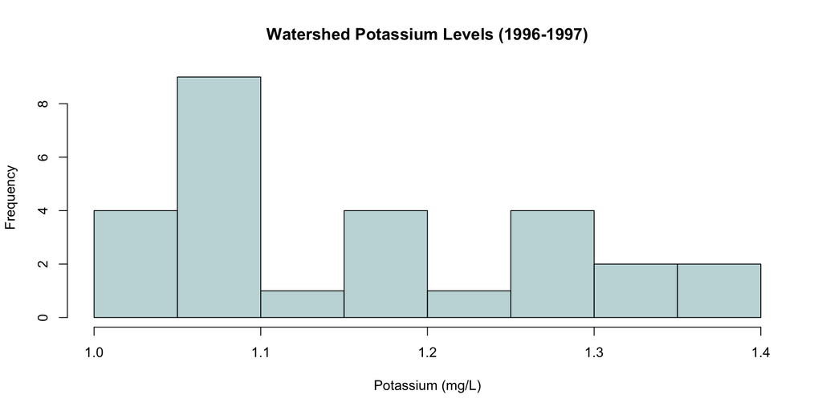

## Mean

$$\bar x = \frac{1}{n}\sum_{i=1}^nx_i$$

$$\mu = \frac{1}{N}\sum_{i=1}^n x_i$$

- “Average”
- Most common measure of center
- Take all the values in the data, add them up, divide by the number of data points

## Mean

$$\begin{array}{|c|c|c|c|c|}
\hline
1.92 & 1.4 & 1.45 & 1.25 & 1.23 \\
\hline
\end{array}$$

$$\begin{aligned}
& \bar x = \frac{1}{n}\sum_{i=1}^nx_i\\
\\
& \bar x = \frac{1}{5}(1.92 + 1.4 + 1.45 + 1.25 + 1.23)\\
\\
& \bar x = \frac{1}{5}(7.25)\\
\\
& \bar x = 1.45\\
\end{aligned}$$

## Resistance

$$\begin{array}{|c|c|c|c|c|c|}
\hline
1.92 & 1.4 & 1.45 & 1.25 & 1.23 & \boldsymbol{6.52}\\
\hline
\end{array}$$

$$\bar x = \frac{1}{6}(7.25+6.52)=2.295$$

$$\begin{array}{|c|c|c|c|c|c|}
\hline
1.92 & 1.4 & 1.45 & 1.25 & 1.23 & \boldsymbol{0.01}\\
\hline
\end{array}$$

## Resistance

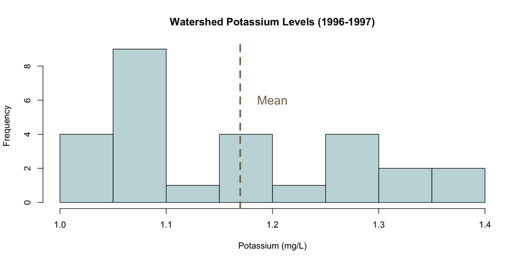

## Median

$$\begin{array}{|c|c|c|c|c|}
\hline
1.92 & 1.4 & 1.45 & 1.25 & 1.23 \\
\hline
\end{array}$$

- The simplest measure of center
- “True” center or middle value
- Organize data from *lowest* to *highest* value
  - If $n$ is odd: Choose position ${(n+1)\over2}$ in the ordered data set
  - If $n$ is even: Pick $n\over 2$ and ${n \over 2}+1$ and average the two data points

## Derivation

$$\begin{array}{|c|c|c|c|c|}
\hline
1.23 & 1.25 & 1.4 & 1.45 & 1.92 \\
\hline
\end{array}$$

$$\frac{5+1}{2}=\frac{6}{2}=3$$

## Derivation

$$\begin{array}{|c|c|c|c|c|}
\hline
1.23 & 1.25 & \boldsymbol{1.4} & 1.45 & 1.92 \\
\hline
\end{array}$$

$$\frac{5+1}{2}=\frac{6}{2}=3$$

$$\text{Median} = 1.4$$

## Derivation

$$\begin{array}{|c|c|c|c|c|c|}
\hline
1.23 & 1.25 & 1.4 & 1.45 & 1.92 & 6.52\\
\hline
\end{array}$$

$$\frac{6}{2}=3 \quad \& \quad \frac{6}{2}+1=4$$

## Derivation

$$\begin{array}{|c|c|c|c|c|c|}
\hline
1.23 & 1.25 & \boldsymbol{1.4} & \boldsymbol{1.45} & 1.92 & 6.52\\
\hline
\end{array}$$

$$\frac{6}{2}=3 \quad \& \quad \frac{6}{2}+1=4$$

$$\text{Median}=\frac{1.4+1.45}{2}=1.425$$

## Elimination

$$\begin{array}{|c|c|c|c|c|}
\hline
1.23 & 1.25 & 1.4 & 1.45 & 1.92 \\
\hline
\end{array}$$

## Elimination

$$\begin{array}{|c|c|c|c|c|}
\hline
\xcancel{1.23} & 1.25 & 1.4 & 1.45 & \xcancel{1.92} \\
\hline
\end{array}$$

## Elimination

$$\begin{array}{|c|c|c|c|c|}
\hline
\xcancel{1.23} & \xcancel{1.25} & 1.4 & \xcancel{1.45} & \xcancel{1.92} \\
\hline
\end{array}$$

## Elimination

$$\begin{array}{|c|c|c|c|c|}
\hline
\xcancel{1.23} & \xcancel{1.25} & \boldsymbol{1.4} & \xcancel{1.45} & \xcancel{1.92} \\
\hline
\end{array}$$

$$\text{Median}=1.4$$

## Elimination

$$\begin{array}{|c|c|c|c|c|c|}
\hline
1.23 & 1.25 & 1.4 & 1.45 & 1.92 & 6.52\\
\hline
\end{array}$$

$$\begin{array}{|c|c|c|c|c|c|}
\hline
1.23 & 1.25 & 1.4 & 1.45 & 1.92 & 0.01\\
\hline
\end{array}$$

## Elimination

$$\begin{array}{|c|c|c|c|c|c|}
\hline
\xcancel{1.23} & 1.25 & 1.4 & 1.45 & 1.92 & \xcancel{6.52}\\
\hline
\end{array}$$

## Elimination

$$\begin{array}{|c|c|c|c|c|c|}
\hline
\xcancel{1.23} & \xcancel{1.25} & 1.4 & 1.45 & \xcancel{1.92} & \xcancel{6.52}\\
\hline
\end{array}$$

## Elimination

$$\begin{array}{|c|c|c|c|c|c|}
\hline
\xcancel{1.23} & \xcancel{1.25} & \boldsymbol{1.4} & \boldsymbol{1.45} & \xcancel{1.92} & \xcancel{6.52}\\
\hline
\end{array}$$

## Skewness

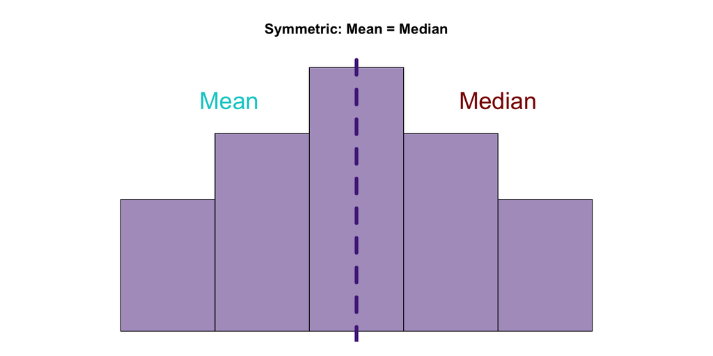

## Skewness

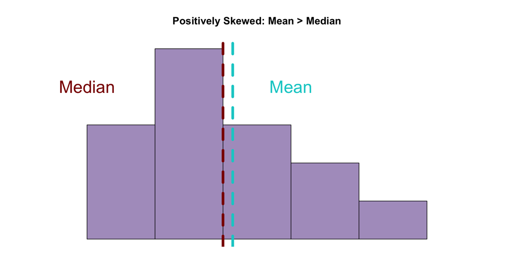

## Skewness

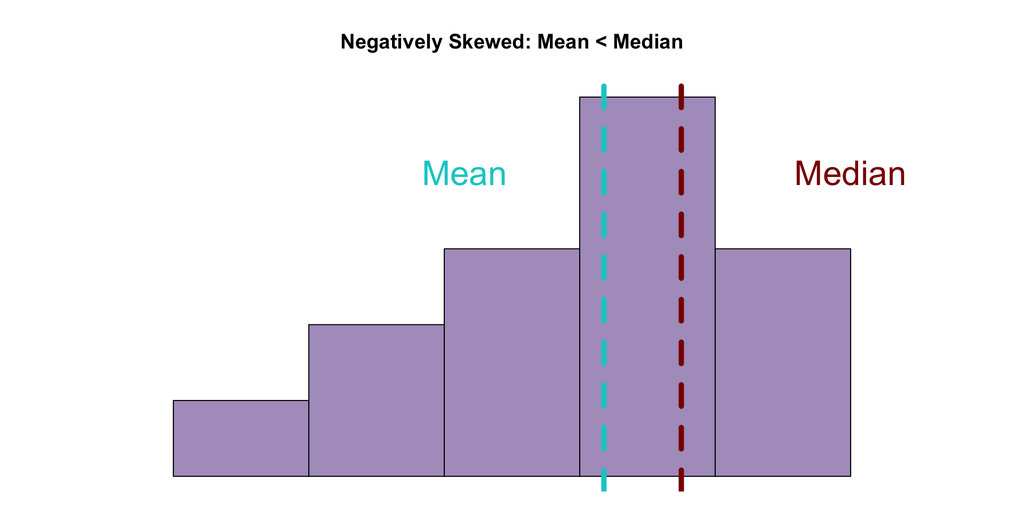

## Frequency

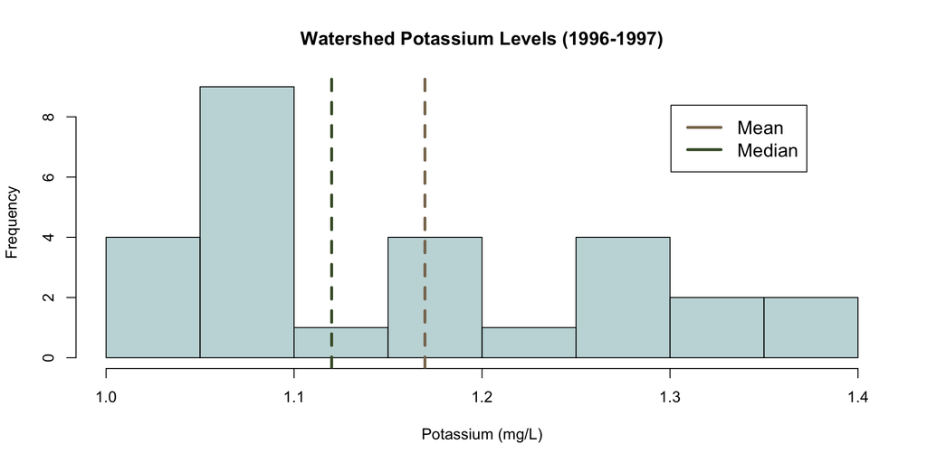

## Frequency

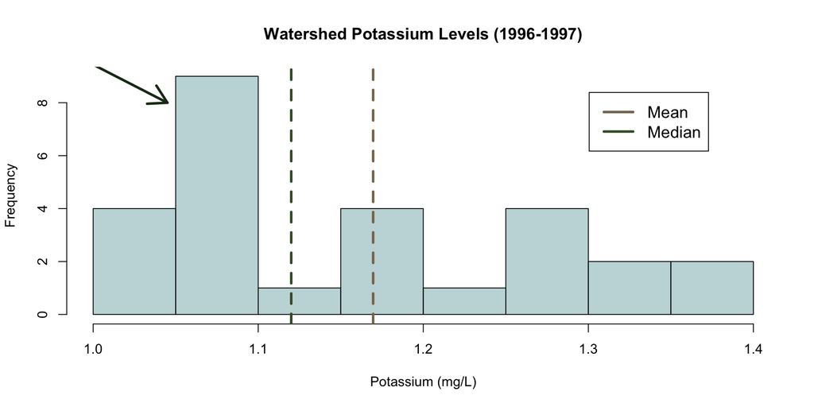

## Mode

$$\begin{array}{|c|c|c|c|c|}
\hline
\boldsymbol{3} & \boldsymbol{3} & 5 & 7 & 12 \\
\hline
\end{array}$$

- Most frequent observation
- Resistant
- Not always very informative
- Easy to skew in a few cases
- Imagine a homogeneous data set

## Mode

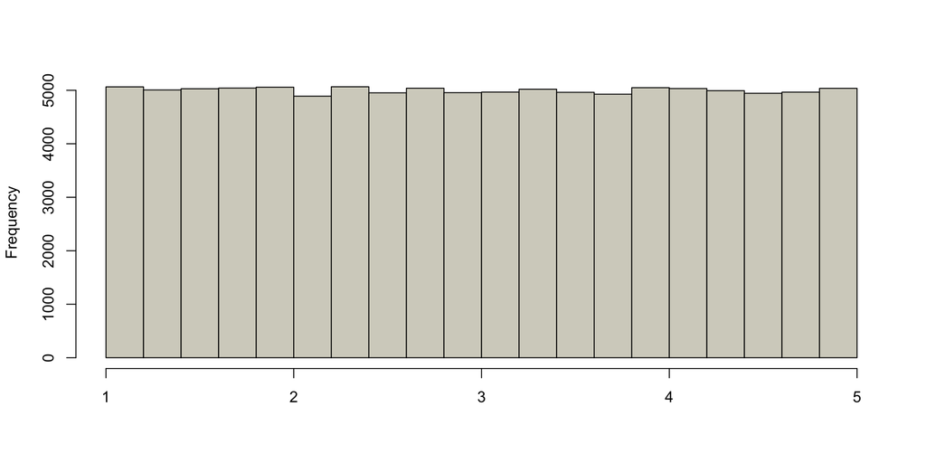

# Measures of Spread

## Spread

How can we look at everything going on *between* the data?

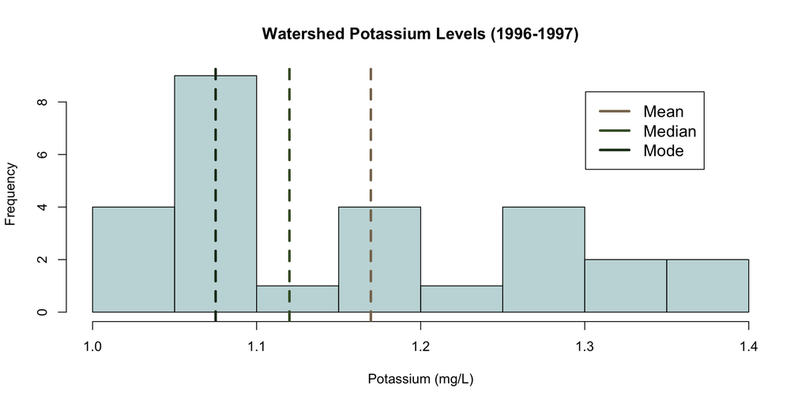

## Range

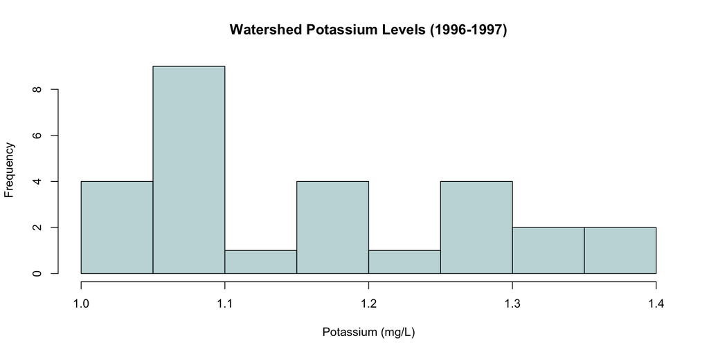

## Range

Difference between the largest and smallest data value

$$\text{Range} = \text{Maximum} - \text{Minimum}$$

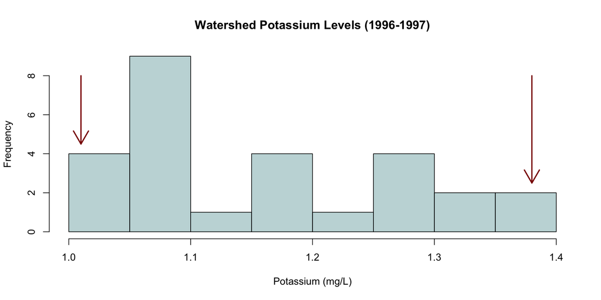

## Range

$$\text{Range} = 1.40 - 1.01 = 0.39$$

$$\begin{array}{|c|c|c|}
\hline
\text{Mean} & \text{Median} & \text{Range} \\
\hline
1.17 & 1.12 & 0.39 \\
\hline
\end{array}$$

- Decent context to the data
- Reduces reliance on graphics

## Range

- Same general information as the graphic

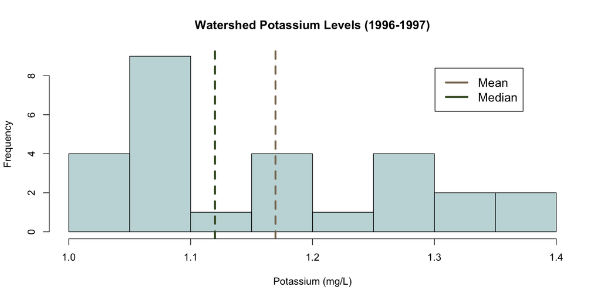

## Range

- “How can we break this?”

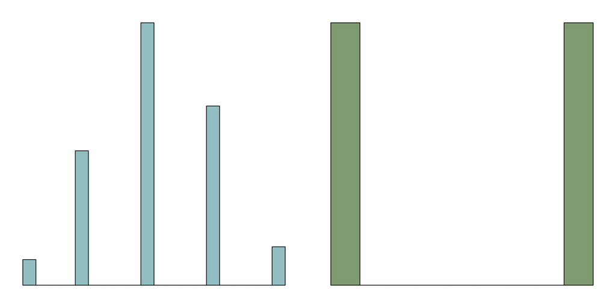

## Spread

- How can we describe the degree with which B is *clustered*?

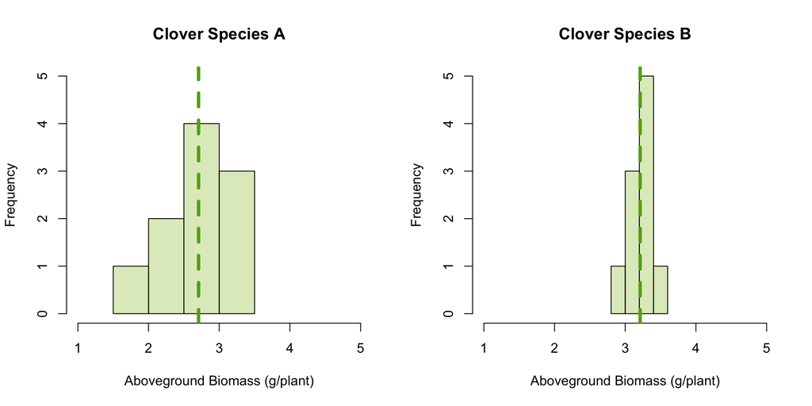

## Variance

- Start with the mean

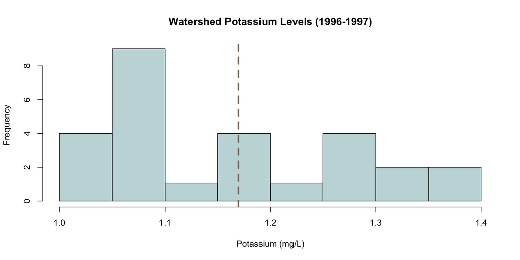

## Variance

- “Center” the data around the mean

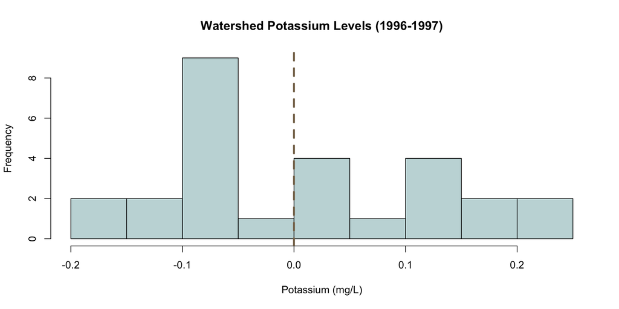

## Variance

- What happens if we add all of these values?

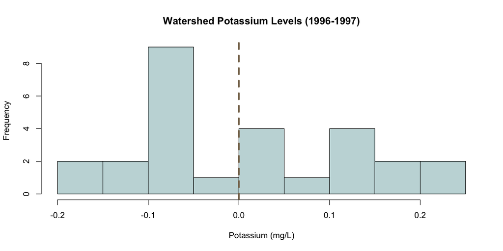

## Variance

- Absolute values are nice and intuitive

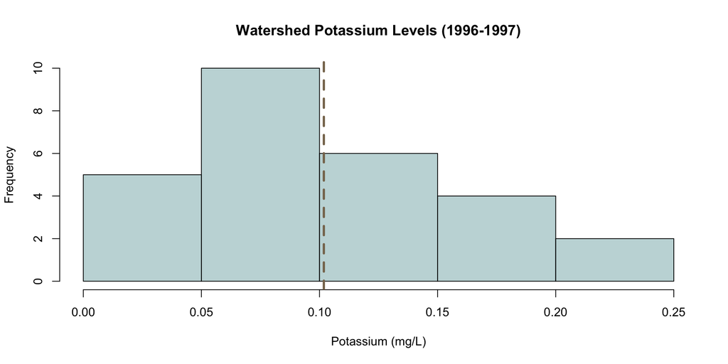

## Absolute Values

$$|x|=\begin{cases}
x, & x\ge 0 \\
-x, & x \lt 0
\end{cases}$$

- Absolute values are nasty in practice
- Nastier with matrix algebra/calculus

## Variance

- Squaring is easier to do

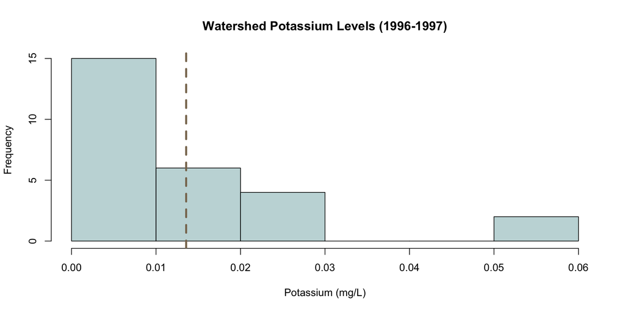

## Variance

- Population

$$\sigma^2=\frac{1}{N}\sum_{i=1}^n(x_i-\mu)^2$$

- Sample

$$s^2=\frac{1}{n-1}\sum_{i=1}^n(x_i-\bar x)^2$$

## Variance

$$\begin{array}{|c|c|c|c|c|}
\hline
1.92 & 1.4 & 1.45 & 1.25 & 1.23 \\
\hline
\end{array}$$

## Variance

$$\begin{aligned}
\bar x = \ 1.45 \text{ mg/L}\\
\end{aligned}$$

## Standard Deviation

$$\sigma = \sqrt{\sigma^2}$$

$$s = \sqrt{s^2}$$

$$s=\sqrt{0.06236 \text{ mg}^2/\text{L}^2} = 0.2497198 \text{ mg/L}$$

- Fundamentally achieves the same thing as absolute difference
- Analytically simpler

## Empirical Rule

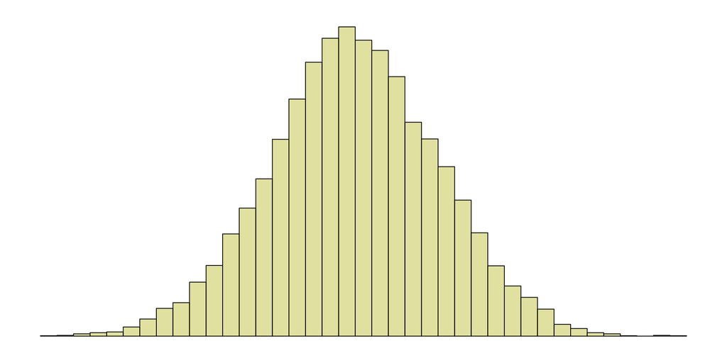

## Empirical Rule

$$\approx 68\% = \begin{cases}
\mu - \sigma \\
\mu + \sigma
\end{cases}$$

$$\approx 95\% = \begin{cases}
\mu - 2\sigma \\
\mu + 2\sigma
\end{cases}$$

$$\approx 99.7-100\% = \begin{cases}
\mu - 3\sigma \\
\mu + 3\sigma
\end{cases}$$

## Empirical Rule

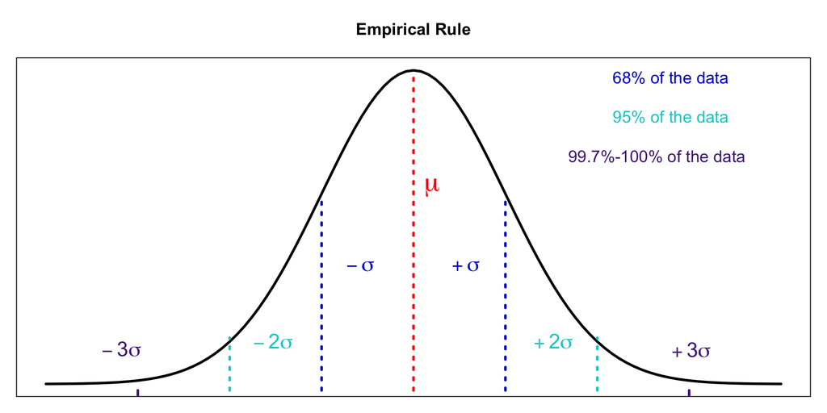